# Reef Fish Abundance Across Time

The raw data compares the presence and absence of 470 coral reef fish species in 5 dive sites in Papua New Guinea, as well as a historical museum collection from one site (Bootless Bay, circa 1881). This analysis examines changes in species richness in Bootless Bay over time, and whether fishing pressure correlates to any changes seen.

## Modifying Raw Data

To begin analyzing the raw data, I used dplyr commands to select columns relevant to my research interest[^1]. I used the filter commmand to filter out rows where species were not present at either location, and to eliminate a row provided in the raw data totaling the amount of species seen at each location.

```r
reef_fish_bootless <- select(reef_fish, Genus, species, Bootless, Museum.Bootless, Fished) %>%
  filter(Bootless > 0 | Museum.Bootless > 0) %>%
  filter(Bootless < 50)
```

## Separating by Fishing Pressure

After isolating the data I needed, I made separate data frames for species that were fished and not fished. This would later help me see if fishing pressure had anything to do with what trends might appear.

```r
reef_fish_bootless_fished <- filter(reef_fish_bootless, Fished == "fished" | Fished == "Fished")

reef_fish_bootless_notfished <- filter(reef_fish_bootless, Fished == "not fished")
```

## Making Useful Tables

After the raw data was sorted, I grouped all the reef fish by genus, then summed the sepcies seen per genus in Bootless Bay now vs. the museum collection. The “n_species” column showed the total sum of species per genus seen across both locations.

```r
reef_fish_bootless_sp <- group_by(reef_fish_bootless, Genus) %>%
  summarise(
    bootless = sum(Bootless),
    Museum.Bootless = sum(Museum.Bootless),
    n_species = n())
```

A preview of the first 20 rows of this table is provided below.

| Genus | bootless | Museum.Bootless | n_species |
| --- | --- | --- | --- |
| Abalistes | 1 | 0 | 1 |
| Abudefduf | 2 | 1 | 2 |
| Acanthurus | 9 | 4 | 11 |
| Aluterus | 1 | 0 | 1 |
| Amblyglyphidodon | 3 | 0 | 3 |
| Amphiprion | 5 | 1 | 5 |
| Anyperodon | 1 | 0 | 1 |
| Balistapus | 1 | 0 | 1 |
| Balistoides | 2 | 0 | 2 |
| Caesio | 3 | 2 | 3 |
| Calotomus | 2 | 0 | 2 |
| Carangoides | 1 | 0 | 1 |
| Caranx | 2 | 2 | 2 |
| Carcharhinus | 1 | 0 | 1 |
| Cephalopholis | 3 | 1 | 4 |
| Cetoscarus | 1 | 0 | 1 |
| Chaetodon | 16 | 13 | 17 |
| Chelmon | 1 | 1 | 1 |
| Chlorurus | 3 | 1 | 3 |
| Chromis | 8 | 1 | 9 |

I repeated this process for the data frames organized by fishing pressure.

```r
bootless_fished_sp <- group_by(reef_fish_bootless_fished, Genus) %>%
  summarise(
    bootless = sum(Bootless),
    Museum.Bootless = sum(Museum.Bootless),
    n_species = n())

bootless_notfished_sp <- group_by(reef_fish_bootless_notfished, Genus) %>%
  summarise(
    bootless = sum(Bootless),
    Museum.Bootless = sum(Museum.Bootless),
    n_species = n())
```

## Graphing Data

After establishing the relationships numerically in data frames, I made scatterplots to visually represent whatever trends might exist. I used ggplot2 to plot two scatterplots on one graph; the blue points represent species per genus seen at Bootless Bay in the 21st century, and the red points represent species per genus present in the museum collection (1881-1889). Both of these are plotted against the total species count seen across both locations for comparsion. I added trasparency to the points to make the density of overlapping points clear.

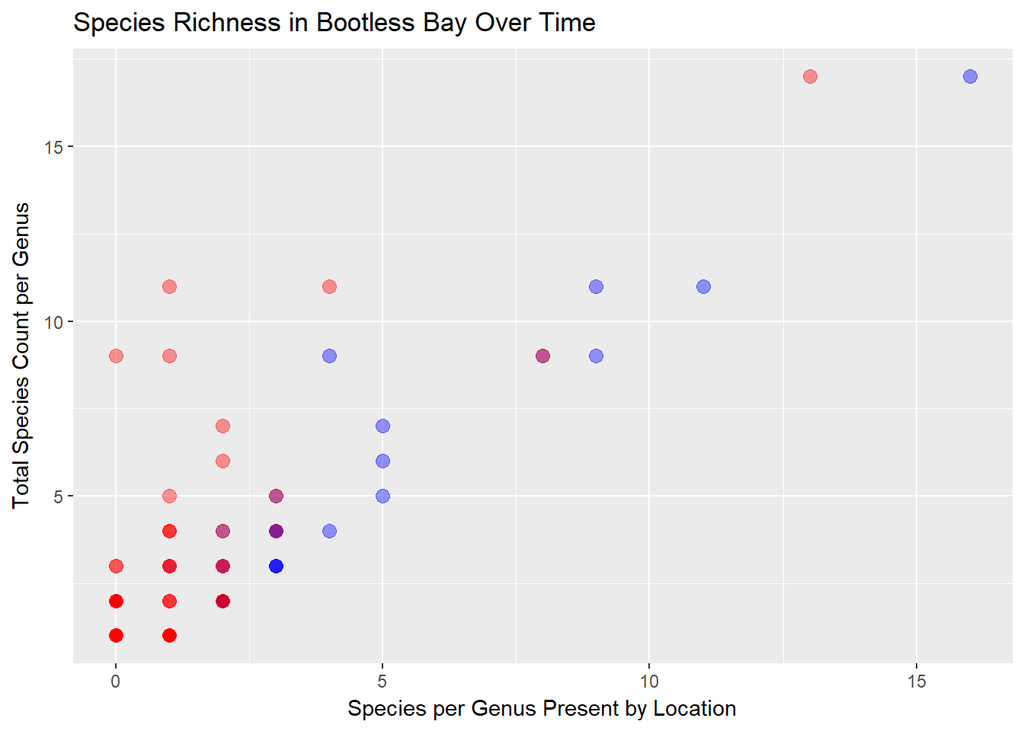

This graphs shows that there is in fact higher species richness in modern studies of Bootless Bay, indicated by slightly higher species count per genus compared to the total species presence. This could be the result of indroduction of non-native species via aquarium trade or ballast water. It’s also possible that the museum collection does not accurately represent the full diversity of species in Bootles Bay in 1881.

I repeated this process for the data separated by fishing pressure.

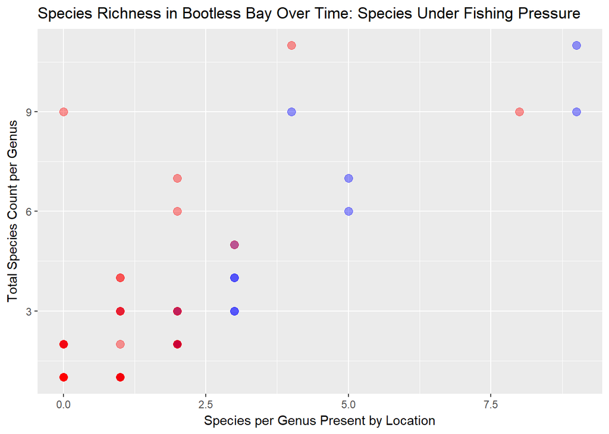

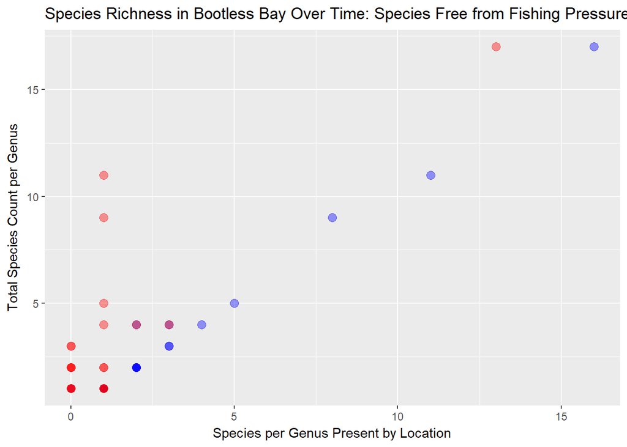

These graphs show similar trends, with slightly more species seen in more present times compared to the total species count.

[^1]: Specifically, I selected columns with the following data: Genus, species, presence/absence in Bootless Bay (21st century), presence/absence in Bootless Bay museum collection (1881-1889), and fishing pressure (noted by fished/not fished).